# US Crime Statistics

Andrew Brown

March 6, 2019

# Table of Contents

1. Data Acquisition
2. Data Description
3. Prominent Features and General Information
4. Interesting Trends

## Data Acquisition

This data set was found on the Federal Bureau of Investigation’s website https://ucr.fbi.gov/crime-in-the-u.s/2016/crime-in-the-u.s.-2016/topic-pages/tables/table-2. The FBI used their records of crime in the United States to create the data set and uploaded it online. On the site I clicked the “download excel” button near the top left of the page. I used Microsoft Excel to edit the file and remove some unnecessary information and to convert the file to a csv I could use within R. I have included the csv file along with this report. Finally, I imported the csv file into R and used tools within R to make a few more changes to the data set and make it easier for me to read.

## Data Description

This data set is a recording of the number of crimes committed in the United states by crime type and by region. It keeps track of 10 different types of crime: Violent Crime, Murder and Nonnegligent Manslaughter, Rape (revised definition), Rape (legacy definition), Robbery, Aggravated Assault, Property Crime, Burglary, Larceny Theft, and Motor Vehicle Theft. It records the total number of these crimes committed in one year in each of the 50 states (plus Puerto Rico and District of Columbia) as well as the total for the US and the total for 13 bigger regions of the US. The data was recorded for two consecutive years, 2015 and 2016.

## Prominent Features and General Information

There aren’t any noticeable instances where a certain region has a lot of one type of crime but not a lot of another. Crime itself basically follows the same pattern regardless of location, with the same types of crimes being more prominent than others. Based on the total numbers of crimes committed for each individual crime type from 2015 and 2016 combined, the most committed crime was property crime and the least committed crime was murder and nonnegligent manslaughter. Each type of crime is shown on this bar graph.

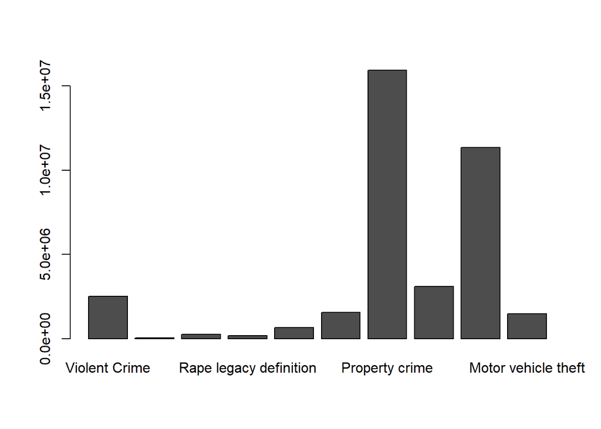

The bars along the X-axis (from left to right respectively) are Violent Crime, Murder and Nonnegligent Manslaughter, Rape (revised definition), Rape (legacy definition), Robbery, Aggravated Assault, Property Crime, Burglary, Larceny Theft, and Motor Vehicle Theft. The Y-axis represents number of crimes committed.

## Interesting Trends

### I.

This graph shows the rape (revised definition) rate from 2016 for each state and Puerto Rico and District of Columbia.

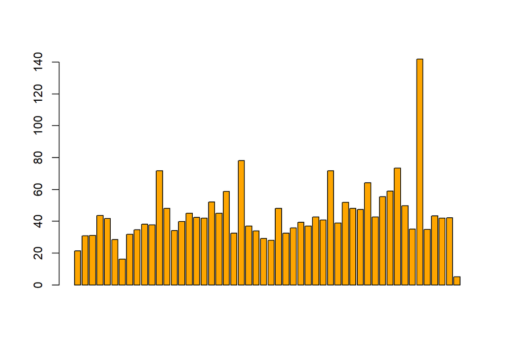

Alaska has the highest rape rate at 141.9 per 100,000 people. DC has the 2nd highest at 78.1, and New Mexico is 3rd with 73.3. I found it fascinating that Alaska’s was so much higher than any other state, but aside from Alaska, most of all the other states form a fairly tight distribution without much variance.

### II.

These graphs show a comparison of the different types of crimes from 2015 and 2016.

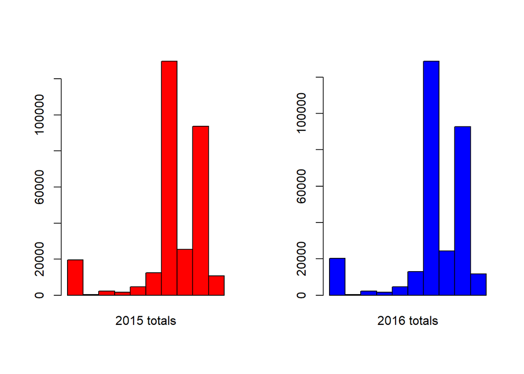

The Y-axis shows the totals of the crime rates for each type of crime. This means that the height of the bar represents the sum of every state’s crime rate for that specific crime. These two graphs are almost identical, which shows that from 2015 to 2016 crime really didn’t go up or down, it was just a normal small fluctuation.

### III.

This graph represents each of the 50 state’s (plus DC and Puerto Rico) total crime rate for 2016.

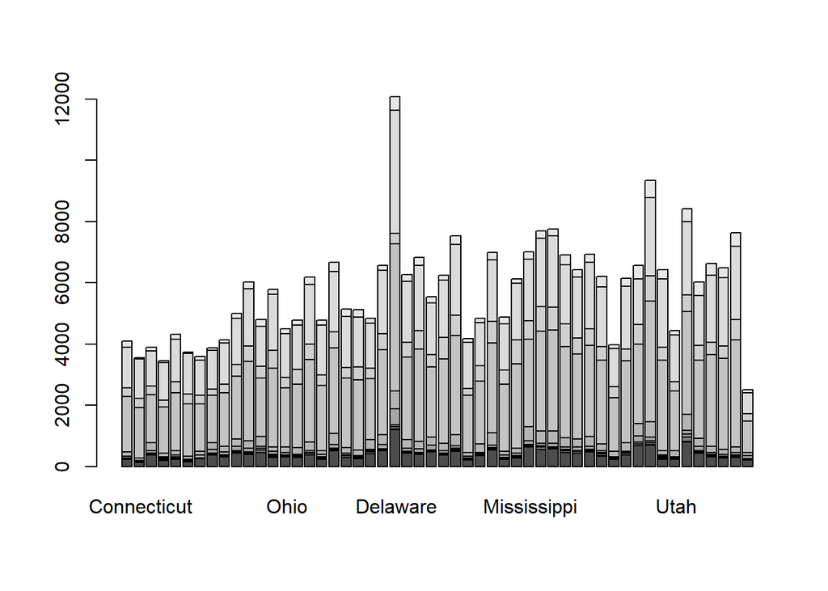

The entire bar is the total of all the crime rates, but the different colors within each bar represent the different types of crime. DC is the tallest bar, which means it has the highest overall crime rate. DC also happens to have the highest crime rate in violent crime, murder and nonnegligent manslaughter, robbery, aggravated assault, property crime, and larceny theft. The second highest overall crime rate is New Mexico, and Alaska is 3rd. Puerto Rico has the lowest crime rate, New Hampshire has the 2nd lowest, and Maine the third lowest. It’s difficult to make a conjecture about crime rates based on this information, DC has a very compact population, but Alaska does not for example. But they are both very high in crime rates.

### IV.

These graphs show the correlation between burglary and all other types of crime.

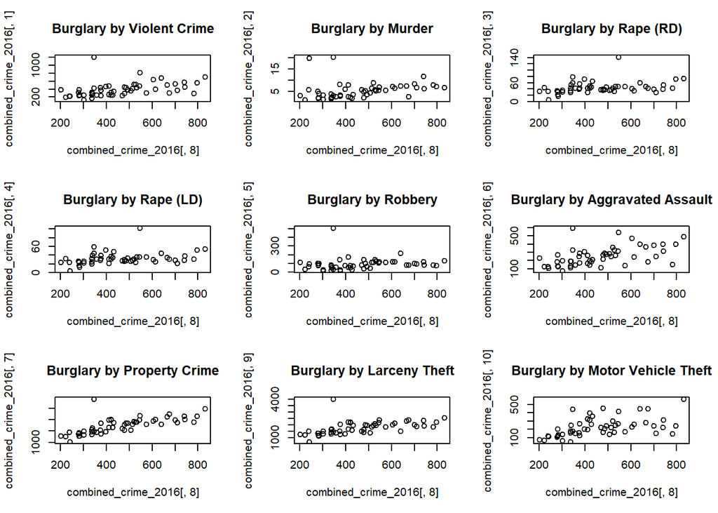